# The Politics of Corruption

Lecture 15: What You Take With You

Bogdan G. Popescu

bgpopescu@tec.mx

Tecnológico de Monterrey

# One Course, One Question

## The question we kept asking

Fifteen sessions, from a traffic stop in Mexico City to a shell company in the Caribbean.

Underneath every one of them was a single question:

> **Almost nobody defends corruption. So why is it everywhere — and what has ever actually made it go away?**

Today there is no new material. Just the answer — in four questions, told through the slides you are most likely to still remember.

## Four questions, one semester

| **Recognize** | What is corruption, when cases look alike? |
| --- | --- |
| **Explain** | Why does it persist, when nobody defends it? |
| **Measure** | How do we know how much there is? |
| **Reduce** | What actually works? |

Four questions you can put to any country, any government, any institution — and the first one you do yourselves, next.

Everything this semester sits in one of those four rows. If you remember the four questions in ten years, the course did its job.

## Recognize — August 10, and your four votes

Four real situations. Three votes: *clearly corrupt*, *not corrupt*, *it’s complicated*.

|  | Case | Where |  |
| --- | --- | --- | --- |
| **1** | A police stop | Mexico | 200 pesos · no ticket |
| **2** | Despensas before the vote | Mexico | groceries · names noted |
| **3** | The revolving door | United States | regulator supervises a bank, the bank hires them |
| **4** | La Estafa Maestra | Mexico | universities · shells · 7,670 million pesos |

I asked you to write your votes down, and said we would come back to them. This is that slide.

## Case 1 — Why does bribery survive?

Mexico

Suppose the official fine is 1,000 pesos. Instead, the officer accepts 200.

- The **driver saves 800 pesos**.
- The **officer earns 200 pesos**.
- The **government loses 1,000 pesos** in revenue.

**Who has an incentive to report the bribe?**

[figure not shown]

The same photograph you saw on 10 August. Photo: ProtoplasmaKid, Wikimedia Commons, CC BY-SA 4.0.

You can now explain and classify this transaction:

- Bribery with theft (S3)
- Speed money (S10)
- Measurable through experience surveys (S8)

The driver saves, the officer earns, and the public loses.

## Case 2 — The same gift, four different exchanges

Mexico

A politician gives a family a bag of groceries before an election.

**What does the family have to do in return?**

- Meet public eligibility rules → **Programmatic distribution**
- Continue supporting the party → **Clientelism**
- Vote for a particular candidate → **Vote buying**
- Simply show up to vote → **Turnout buying**

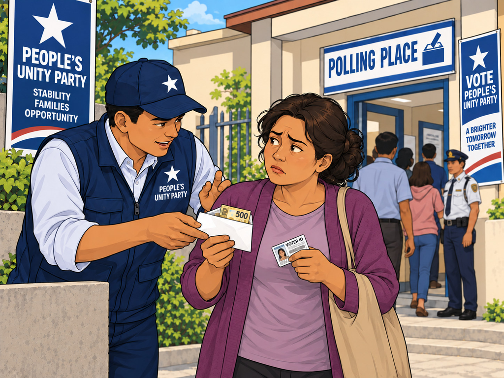

**When does it become corruption?**

When public resources are misused for political gain.

## Two people you followed all semester

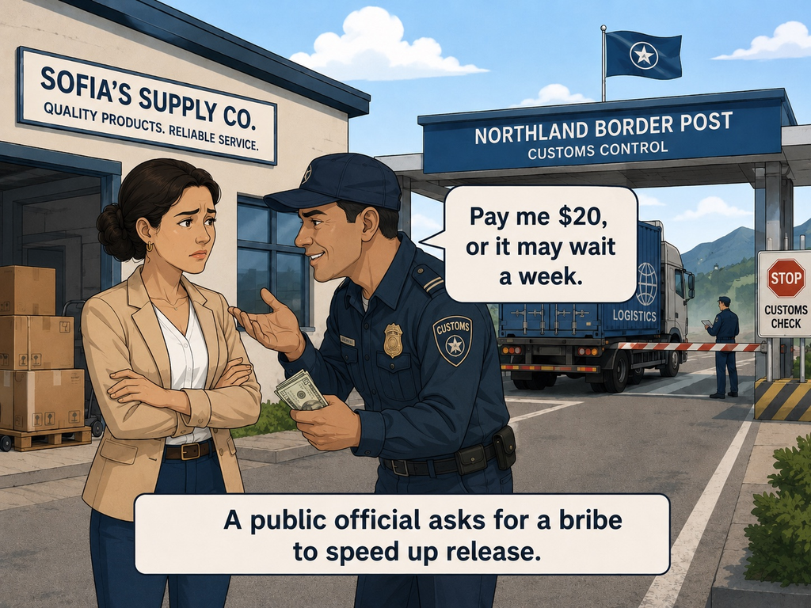

**Sofía**, Session 3 — only that officer could release the cargo, and only he decided when.

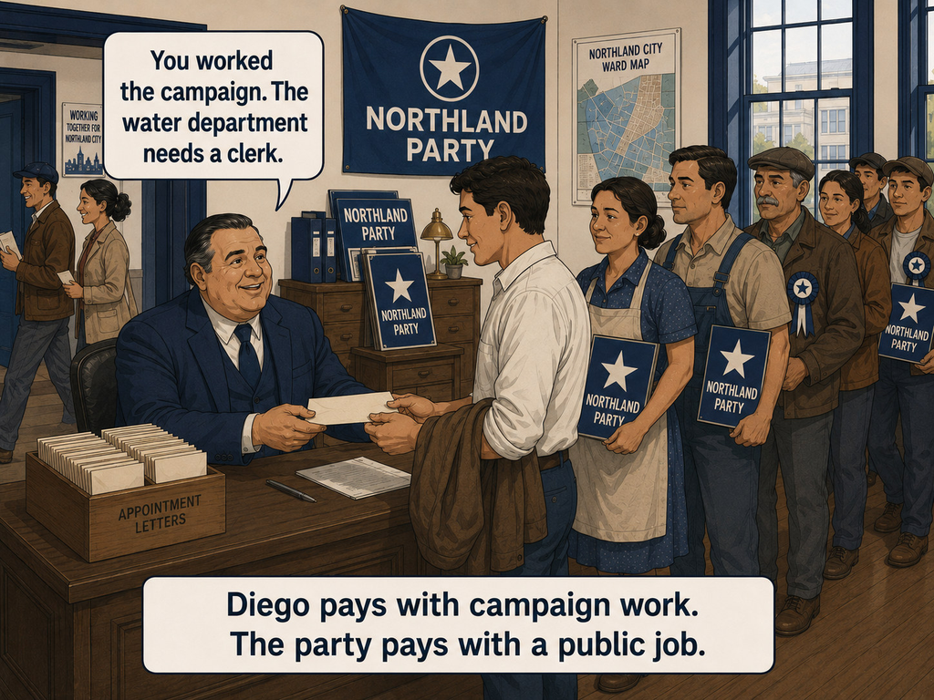

**Diego**, Session 6 — three months of evenings, and the payment was never money.

Neither of them did anything unusual. Between them they carry the whole course.

## Explain — Sofía stood still

[figure not shown]

Even honest people get trapped. That is what an **equilibrium** is — and it is why punishing individuals so often changes nothing.

## Explain — plata o plomo

[figure not shown]

**Diego pays $100.**

[figure not shown]

**The cartel pays $40** — and supplies the other $60 as a threat.

Criminals get the same favour by paying less and threatening more. Bribes and bullets are **substitutes** — so the money changing hands *understates* how captured an office is.

## Measure — what the gravel hid

[figure not shown]

- Engineers dug up 477 Javanese roads and compared what was built with what was billed: **24% missing** (S8)
- The prices were honest. The **quantities** were not
- Everyone knows what gravel costs. Nobody can look at a heap and say how much arrived

People steal what is hardest to check.

Photo: Greg Willis, Wikimedia Commons, CC BY-SA 2.0.

## Reduce — Can fighting crime increase violence?

Remember Diego? The police arrested the man who was extorting him. He thought his problems were over.

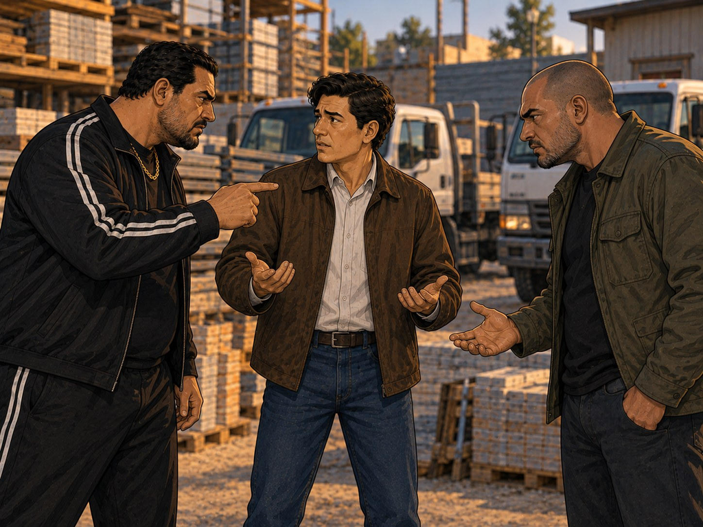

**Did this actually happen in Mexico?**

+57

Additional homicides per 100,000 residents per year in municipalities where the PAN barely won, compared with those where it barely lost. Dell (2015), Session 12.

## Reduce — a speed camera that only works at lunchtime

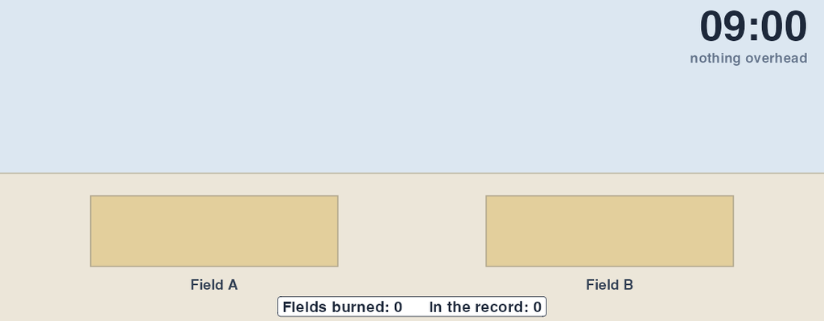

- Punjab officials were told to halve **detected** fires. The satellites pass between 10:30 and 13:30 (S13)
- So the burning moved to the afternoon
- For every 100 fewer detected fires, only about **22** had actually stopped

**Goodhart’s law:** when a measure becomes a target, people improve the measure.

Twice now, the same idea: people adapt to a policy, sometimes in ways nobody intended — and that is what decides whether it worked.

## Reading the news: Has corruption really fallen?

Hypothetical headline

### New anti-corruption programme cuts corruption by 30%

| Last year | This year |
| --- | --- |
| **1,000** complaints | **700** complaints |

- Perhaps fewer officials are demanding bribes.
- Perhaps fewer citizens are reporting them.
- Perhaps corruption would have fallen without the programme.

Fewer complaints do not necessarily mean less corruption.

Critical analysis (S2) · Measurement (S8)

## Reading the news — Has AI caught corruption?

Hypothetical headline

### Artificial intelligence identifies 500 corrupt companies

An algorithm examines government contracts and flags 500 companies as suspicious.

**Have we found 500 corrupt companies?**

- Some suspicious companies may be innocent.
- Some corrupt companies may escape detection.
- Investigators still need to examine the evidence.

An algorithm can identify suspects. It cannot establish guilt by itself.

Kleptocracy (S11) · Technology (S13)

## You read the same news differently now

| The headline says… | You now ask… |
| --- | --- |
| Corruption fell by 30%. | What exactly was measured? |
| The programme worked. | Compared with what? |
| AI caught 500 corrupt companies. | What does the evidence actually prove? |
| We removed the corrupt officials. | Have their incentives changed? |

The news hasn’t changed.

**The way you read it has.**

## A promise I made on August 10

On the first day, I told you what you would be able to do by the end of this course.

| What I promised you | What you can do today |
| --- | --- |
| Distinguish bribery, fraud, clientelism, patronage, state capture | **Recognize corruption in its many forms**, even when it is disguised or legal. |
| Explain why corruption persists in some countries | **Explain why even honest people participate** in corrupt systems. |
| Weigh what the evidence says corruption costs | **Evaluate the evidence** behind claims about corruption, poverty and economic growth. |
| Compare how some countries reduced corruption, and why | **Explain why some reforms succeed and others backfire.** |
| Read a study and say what it actually established | **Read research independently**, identify weaknesses and reach your own conclusions. |

In August, I asked what you thought.

Today, I can ask what you think, why you think it, and what evidence supports it.

## More than a course on corruption

- **Read independently** — understand difficult material without relying on someone else’s explanation.
- **Evaluate evidence** — recognize when a statistic does not support a conclusion.
- **Communicate clearly** — explain a complicated argument in ten minutes.
- **Defend an argument** — respond to difficult questions without relying on a script.

You may never work on corruption.

But these skills will remain useful.

## You should be proud of what you accomplished

16

**Required readings**

Original academic research, with 28 additional readings available.

29

**Presentations**

Explaining and defending complex arguments as a class.

~20

**Critical questions each**

Developing your own judgment.

Your reading list included articles from some of the world’s leading academic journals:

- *Quarterly Journal of Economics*
- *American Political Science Review*
- *American Economic Review*
- *Journal of Political Economy*

## You should be proud of what you accomplished

The kind of research students encounter in leading graduate programs.

You did not just read this research. You learned to question it.

**That is an achievement. Be proud of it.**

# Why I taught the way I did

## Why I asked so much of you

Every demanding task had a purpose.

| What I asked you to do | What I wanted you to learn |
| --- | --- |
| Read difficult academic articles | **Understand complex information** on your own |
| Write questions before class | **Think for yourself** before hearing someone else’s opinion |
| Present in ten minutes | **Explain complicated ideas** in simple words |
| Answer difficult questions | **Think clearly**, even when you are put on the spot |

These are skills you will need in job interviews, meetings, other courses, and important decisions throughout your life.

I expected a lot from you because I believed you were capable of a lot.

## Why I was demanding

| What I asked of you | Why it mattered to me |
| --- | --- |
| Put your phones away | I wanted you to be **mentally present**, not just physically present. |
| Arrive on time and stay | I wanted everyone to be **part of the discussion**. |
| Answer questions, even without raising your hand | I wanted everyone to **practise thinking and expressing their ideas**, not just the most confident students. |

I did not want you to be spectators in your own education.

I wanted every one of you to be an active participant.

## Thank you

bgpopescu@tec.mx

bgpopescu.net/teaching/corruption

## Teaching evaluation

[figure not shown]

forms.gle/3VzPTovn8FxbWSUG9